# introduction + summary

Yizhou Ding

2022-08-15

## Introduction

In this project, I will focus on Washington State incarceration data related to population and race. By using the data from Vera Institute of Justice, I choose to focus on the Asian American Population, Black Population, total population, total jail population in Washington State, because I go to university in UW.

## Summary

In the most recent year, the county where hold the most population in prison is King Country.

Something that surprised me is that despite all the anti-racist, anti-sexist activism that has been going on, this phenomenon still exists.

## Chart 1: Scatter Plot

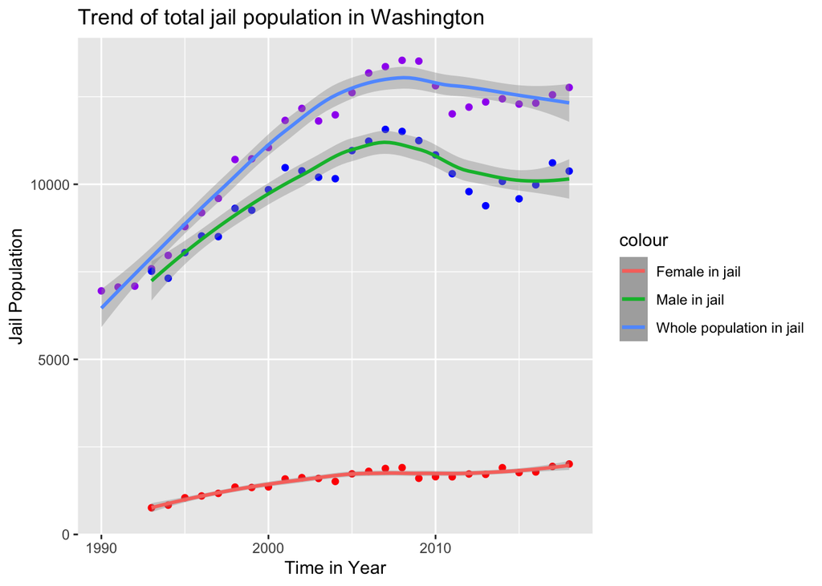

## Chart 2: Pie Chart

The pie chart shows the percentage of each region in jail. We can see that the number of people in the South accounts for a large percentage of crime in the country as a whole. The midwest is the least.

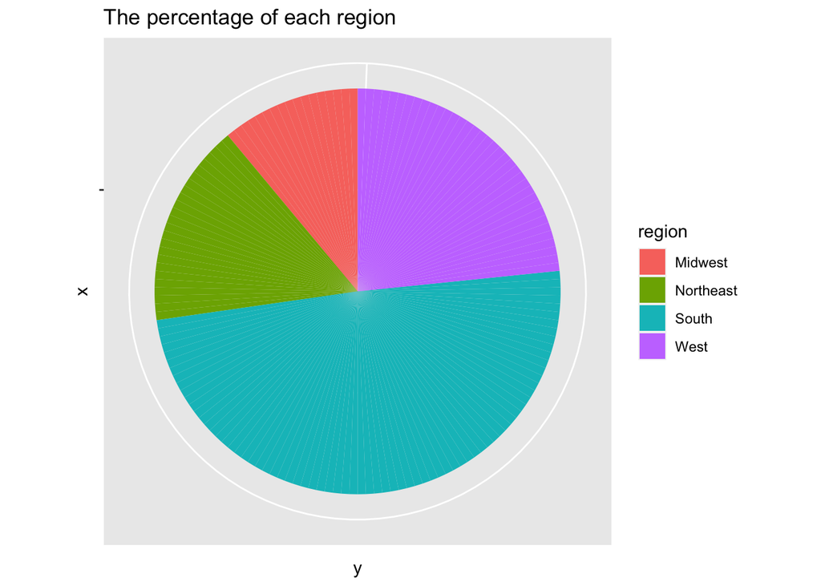

## Chart 3: Map

The map shows the female population in jail in WA. According to the map, a great portion of the female population in jail lies in the King county, the second portion lies in Yakima and the third lies in Spokane. I think the reason king country has the highest crime rate is because it is the area with the highest crime rate in Washington State, and secondly, it has the highest population movement in the area, so it leads to the highest crime rate.

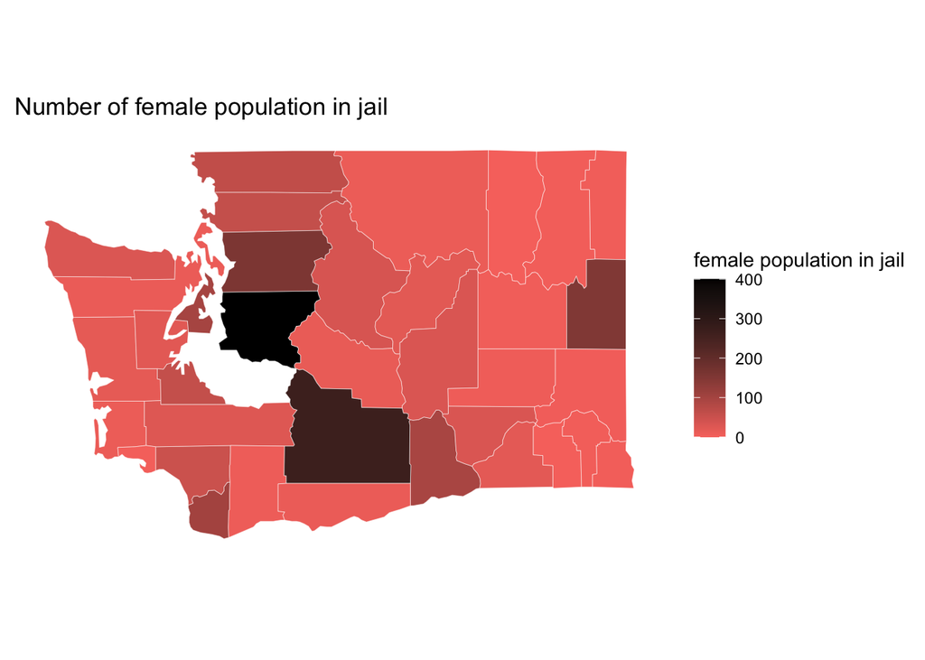